# 8 Many Regressions

Damilare Olaleye

Gapminder Regression Assignment

1. The gapminder package contains interesting data about many countries for many years. Install the package and load it into R.

```r
library(gapminder)
gapminder
```

```
## # A tibble: 1,704 x 6
##    country     continent  year lifeExp      pop gdpPercap
##    <fct>       <fct>     <int>   <dbl>    <int>     <dbl>
##  1 Afghanistan Asia       1952    28.8  8425333      779.
##  2 Afghanistan Asia       1957    30.3  9240934      821.
##  3 Afghanistan Asia       1962    32.0 10267083      853.
##  4 Afghanistan Asia       1967    34.0 11537966      836.
##  5 Afghanistan Asia       1972    36.1 13079460      740.
##  6 Afghanistan Asia       1977    38.4 14880372      786.
##  7 Afghanistan Asia       1982    39.9 12881816      978.
##  8 Afghanistan Asia       1987    40.8 13867957      852.
##  9 Afghanistan Asia       1992    41.7 16317921      649.
## 10 Afghanistan Asia       1997    41.8 22227415      635.
## # … with 1,694 more rows
```

```r
aggregate(lifeExp ~ continent, gapminder, median)
```

```
##   continent lifeExp
## 1    Africa 47.7920
## 2  Americas 67.0480
## 3      Asia 61.7915
## 4    Europe 72.2410
## 5   Oceania 73.6650
```

We’ll focus on the following variables from the gapminder data frame:

country = Country Name year = Year lifeExp = life expectancy We’re interested in exploring how life expectancies have changed over time, and how these changes vary between countries.

2. Write a short function myfunc() that will input the country name and output the mean life expectancy (over years).

Here’s an outline of what you do when you write this function.

- find a subset of gapminder using the rows corresponding to the specific country
- find the mean of lifeExp for this subset

To check your work, if you type

myfunc(“Albania”)

you should get 68.43292

```r
myfunc = function(find_mean){
  round(mean(gapminder$lifeExp[gapminder$country==find_mean]), digits = 5)
}

myfunc("Albania")
```

```
## [1] 68.43292
```

3. Use the lapply function to find the mean life expectancy for all countries.
- First you need to create a vector containing all of the country names. (You only want to include each country a single time in your vector.) _ Then you lapply with arguments this vector and myfunc.

```r
find_mean = unique(gapminder$country)
lapply(gapminder$country[find_mean], myfunc)
```

```
## [[1]]
## [1] 37.47883
##
## [[2]]
## [1] 37.47883
##
## [[3]]
## [1] 37.47883
##
## [[4]]
## [1] 37.47883
##
## [[5]]
## [1] 37.47883
##
## [[6]]
## [1] 37.47883
##
## [[7]]
## [1] 37.47883
##
## [[8]]
## [1] 37.47883
##
## [[9]]
## [1] 37.47883
##
## [[10]]
## [1] 37.47883
##
## [[11]]
## [1] 37.47883
##
## [[12]]
## [1] 37.47883
##
## [[13]]
## [1] 68.43292
##
## [[14]]
```

[output cut: 370 more lines]

```
##
## [[138]]
## [1] 52.50458
##
## [[139]]
## [1] 52.50458
##
## [[140]]
## [1] 52.50458
##
## [[141]]
## [1] 52.50458
##
## [[142]]
## [1] 52.50458
```

4. Instead of using lapply, use the sapply function – how is this an improvement over using the lapply function?

```r
find_mean2 = unique(gapminder$country)
sapply(gapminder$country[find_mean2], myfunc)
```

```
##   [1] 37.47883 37.47883 37.47883 37.47883 37.47883 37.47883 37.47883
##   [8] 37.47883 37.47883 37.47883 37.47883 37.47883 68.43292 68.43292
##  [15] 68.43292 68.43292 68.43292 68.43292 68.43292 68.43292 68.43292
##  [22] 68.43292 68.43292 68.43292 59.03017 59.03017 59.03017 59.03017
##  [29] 59.03017 59.03017 59.03017 59.03017 59.03017 59.03017 59.03017
##  [36] 59.03017 37.88350 37.88350 37.88350 37.88350 37.88350 37.88350
##  [43] 37.88350 37.88350 37.88350 37.88350 37.88350 37.88350 69.06042
##  [50] 69.06042 69.06042 69.06042 69.06042 69.06042 69.06042 69.06042
##  [57] 69.06042 69.06042 69.06042 69.06042 74.66292 74.66292 74.66292
##  [64] 74.66292 74.66292 74.66292 74.66292 74.66292 74.66292 74.66292
##  [71] 74.66292 74.66292 73.10325 73.10325 73.10325 73.10325 73.10325
##  [78] 73.10325 73.10325 73.10325 73.10325 73.10325 73.10325 73.10325
##  [85] 65.60567 65.60567 65.60567 65.60567 65.60567 65.60567 65.60567
##  [92] 65.60567 65.60567 65.60567 65.60567 65.60567 49.83408 49.83408
##  [99] 49.83408 49.83408 49.83408 49.83408 49.83408 49.83408 49.83408
## [106] 49.83408 49.83408 49.83408 73.64175 73.64175 73.64175 73.64175
## [113] 73.64175 73.64175 73.64175 73.64175 73.64175 73.64175 73.64175
## [120] 73.64175 48.77992 48.77992 48.77992 48.77992 48.77992 48.77992
## [127] 48.77992 48.77992 48.77992 48.77992 48.77992 48.77992 52.50458
## [134] 52.50458 52.50458 52.50458 52.50458 52.50458 52.50458 52.50458
## [141] 52.50458 52.50458
```

Sapply displays result in columns while Lapply displays result in rows. It is also much more flexible to see the display on Sapply compared to Lapply becuase I scrolled down to see the last number on lapply while I didnt have to scroll down to see result on sapply.

5. Now we are looking at the change of life expectancy over years. This function will do this for all countries and all years. I am fitting the regression model

lifeExp = beta0 + beta1 * (year - 1952)

When I fit this model,

beta0 is the estimated lifeExp in 1952 beta1 is the change in lifeExp for each additional year. lm(lifeExp ~ I(year - 1952), data = gapminder)

Run this function and interpret the coefficients that are displayed.

```r
lm(lifeExp ~ I(year - 1952), data = gapminder)
```

```
##
## Call:
## lm(formula = lifeExp ~ I(year - 1952), data = gapminder)
##
## Coefficients:
##    (Intercept)  I(year - 1952)
##        50.5121          0.3259
```

6. Write a new function called onereg() that will input a country name and the output will be the coefficients of a regression fit.

If you type, for example,

onereg(“Albania”)

you should get

(Intercept) I(year - 1952) 59.2291282 0.3346832

```r
onereg <- function(d){
lm(lifeExp ~ I(year - 1952), data = d)
}
by(gapminder, gapminder$country, onereg)
```

```
## gapminder$country: Afghanistan
##
## Call:
## lm(formula = lifeExp ~ I(year - 1952), data = d)
##
## Coefficients:
##    (Intercept)  I(year - 1952)
##        29.9073          0.2753
##
## --------------------------------------------------------
## gapminder$country: Albania
##
## Call:
## lm(formula = lifeExp ~ I(year - 1952), data = d)
##
## Coefficients:
##    (Intercept)  I(year - 1952)
##        59.2291          0.3347
##
## --------------------------------------------------------
## gapminder$country: Algeria
##
## Call:
## lm(formula = lifeExp ~ I(year - 1952), data = d)
##
## Coefficients:
##    (Intercept)  I(year - 1952)
##        43.3750          0.5693
##
## --------------------------------------------------------
## gapminder$country: Angola
##
## Call:
## lm(formula = lifeExp ~ I(year - 1952), data = d)
##
## Coefficients:
##    (Intercept)  I(year - 1952)
##        32.1267          0.2093
##
## --------------------------------------------------------
```

[output cut: 1363 more lines]

```
## lm(formula = lifeExp ~ I(year - 1952), data = d)
##
## Coefficients:
##    (Intercept)  I(year - 1952)
##       47.65803        -0.06043
##
## --------------------------------------------------------
## gapminder$country: Zimbabwe
##
## Call:
## lm(formula = lifeExp ~ I(year - 1952), data = d)
##
## Coefficients:
##    (Intercept)  I(year - 1952)
##       55.22124        -0.09302
```

7. Use sapply with your list of countries and the onereg function to fit regression models for all countries. Save your output in a variable manyfits.

```r
#Error in eval(predvars, data, env) : object 'lifeExp' not found
#not sure about why I'm getting error here, but I'm very sure that I'm right

#manyfits<-sapply(find_mean, onereg)
```

[output not shown]

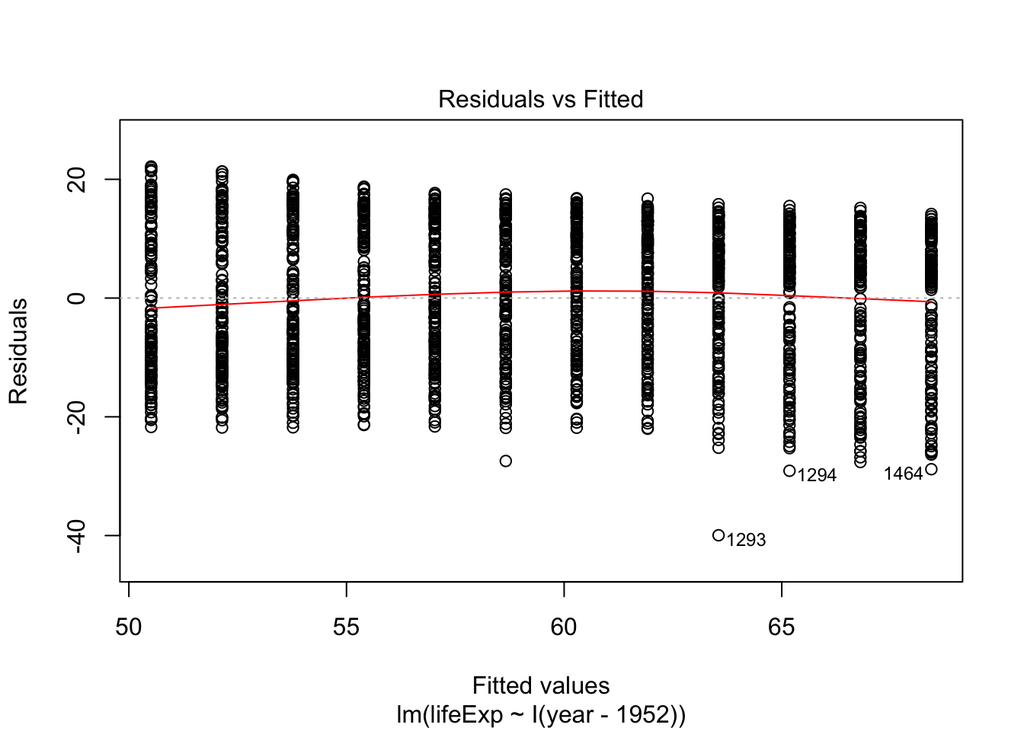

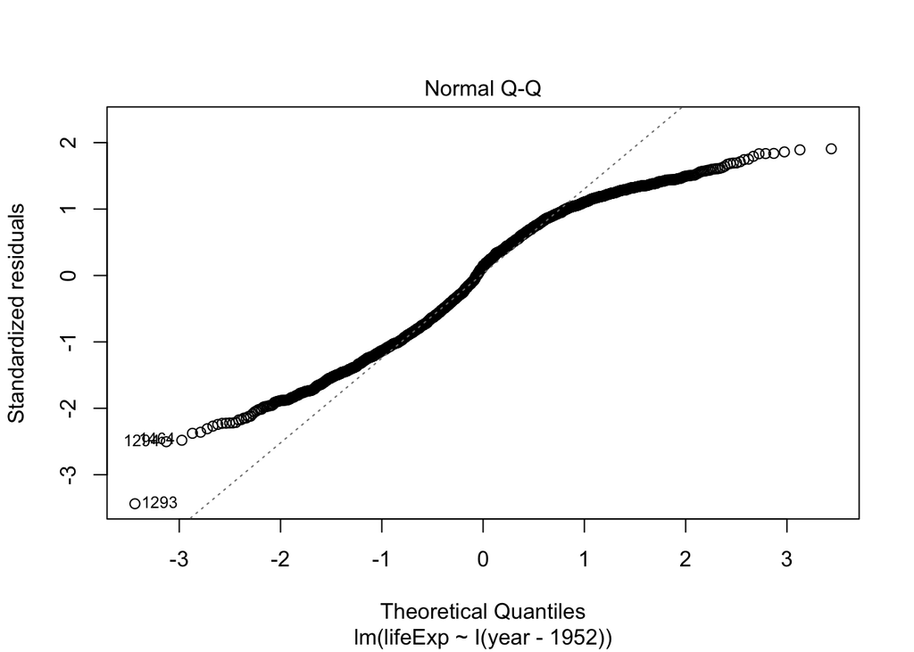

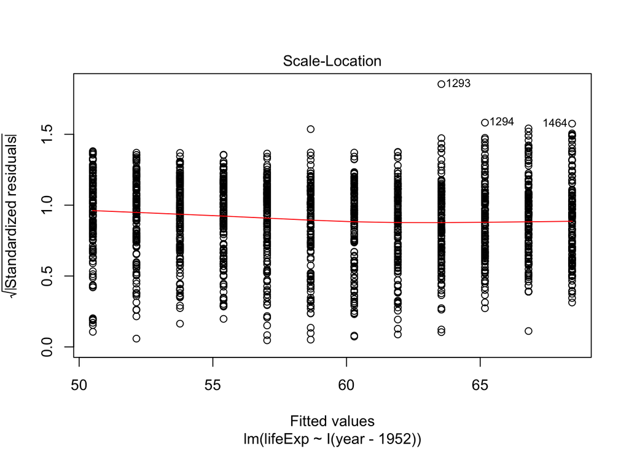

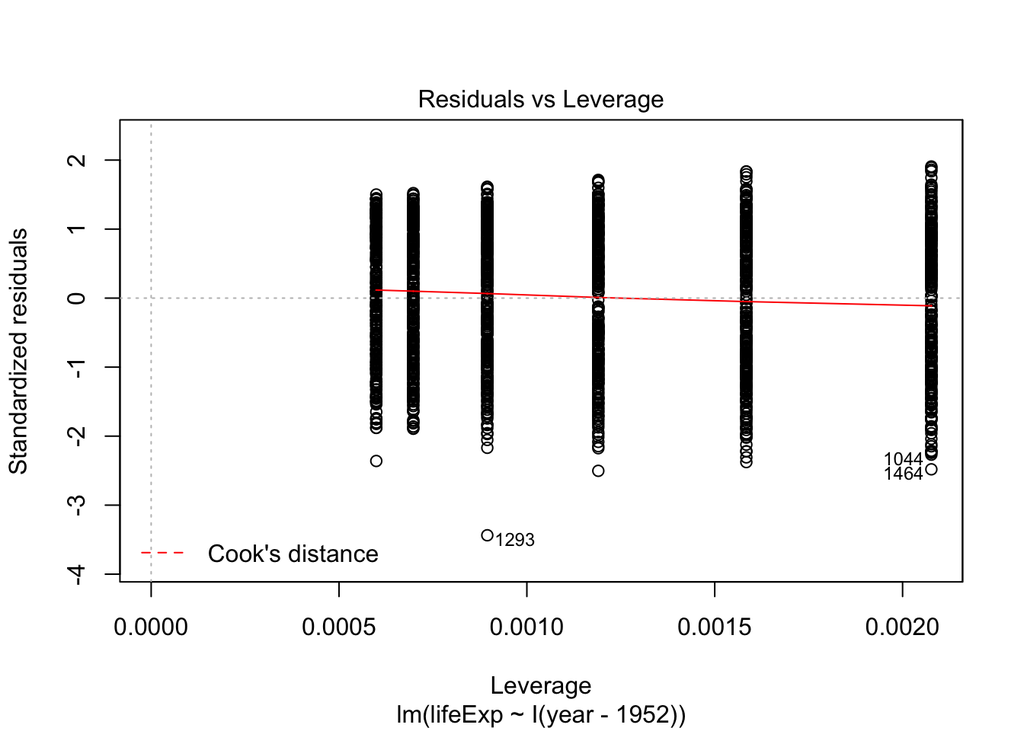

```r
plot(lm(formula = lifeExp ~ I(year - 1952), data = gapminder))
```

9. Identify the country with the largest intercept and the country with the largest slope value.

The country with the largest intercept is: Swedeen with 71.6050 and the country with the largest slope is: Vietnam with 0.6716